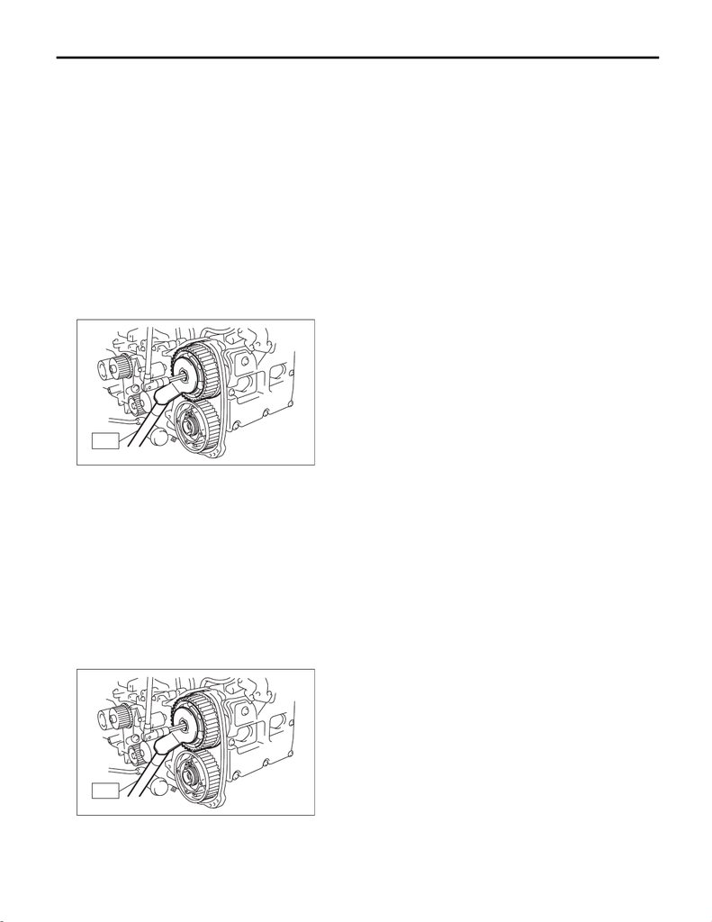

ME(STI)-60

Cam Sprocket

MECHANICAL

16.Cam Sprocket

A: REMOVAL

NOTE:

When replacing a single part, perform the work with

the engine assembly installed to body.

1) Remove the crank pulley. <Ref. to ME(STI)-48,

REMOVAL, Crank Pulley.>

2) Remove the timing belt cover. <Ref. to ME(STI)-

50, REMOVAL, Timing Belt Cover.>

3) Remove the timing belt. <Ref. to ME(STI)-51,

REMOVAL, Timing Belt.>

4) Remove the actuator covers of the intake and

exhaust cam sprockets.

5) Use the ST to lock the cam sprocket, and re-

move the cam sprocket bolt.

ST 499977500 CAM SPROCKET WRENCH

6) Remove the cam sprocket.

B: INSTALLATION

1) Install the cam sprocket.

2) Use the ST to lock the cam sprocket, and install

the cam sprocket bolt.

NOTE:

Do not confuse cam sprockets (LH) and (RH), and

(INT) and (EXH) during installation.

ST 499977500 CAM SPROCKET WRENCH

Tightening torque:

Tighten to 30 N·m (3.1 kgf-m, 22.1 ft-lb) of

torque, and then tighten further by 45°.

3) Attach the actuator covers of the intake and ex-

haust cam sprockets.

NOTE:

Use new O-rings.

Tightening torque:

3.4 N·m (0.3 kgf-m, 2.5 ft-lb)

4) Install the timing belt. <Ref. to ME(STI)-53, IN-

STALLATION, Timing Belt.>

5) Install the timing belt cover. <Ref. to ME(STI)-

50, INSTALLATION, Timing Belt Cover.>

6) Install the crank pulley. <Ref. to ME(STI)-48, IN-

STALLATION, Crank Pulley.>

C: INSPECTION

1) Check the cam sprocket teeth for abnormal wear

and scratches.

2) Make sure there is no free play between cam

sprocket and key.

ME-03332

ST